# Statistical Case Study: Predicting Post-Graduation Earnings

Tim Sheppel

03/07/2026

# Section 0: Setup

```r
library(car)
library(psych)
library(corrplot)
library(ggplot2)
library(Hmisc)
library(dplyr)
library(tidyr)
```

# Section 1: Data Loading and Summary

```r
college_data <- read.csv("collegescorecard.csv")
```

```r
summary(college_data)
```

```
##      unitid         instname             city              state
##  Min.   :100654   Length:1326        Length:1326        Length:1326
##  1st Qu.:152539   Class :character   Class :character   Class :character
##  Median :183067   Mode  :character   Mode  :character   Mode  :character
##  Mean   :182728
##  3rd Qu.:214650
##  Max.   :448840
##     control         adm_rate         sat_avg       enrollment
##  Min.   :1.000   Min.   :  5.69   Min.   : 666   Min.   :  126
##  1st Qu.:1.000   1st Qu.: 53.81   1st Qu.: 976   1st Qu.: 1348
##  Median :2.000   Median : 66.16   Median :1043   Median : 2512
##  Mean   :1.621   Mean   : 64.18   Mean   :1061   Mean   : 5579
##  3rd Qu.:2.000   3rd Qu.: 76.95   3rd Qu.:1122   3rd Qu.: 6499
##  Max.   :2.000   Max.   :100.00   Max.   :1534   Max.   :50919
##     pctpell         pctfloan      avg_net_price     grad_rate
##  Min.   : 6.16   Min.   :  0.00   Min.   : 1776   Min.   : 4.84
##  1st Qu.:26.21   1st Qu.: 49.71   1st Qu.:14236   1st Qu.:42.49
##  Median :35.58   Median : 61.90   Median :18118   Median :53.70
##  Mean   :36.49   Mean   : 60.23   Mean   :18848   Mean   :54.75
##  3rd Qu.:44.89   3rd Qu.: 72.03   3rd Qu.:22790   3rd Qu.:66.27
##  Max.   :94.51   Max.   :100.00   Max.   :41414   Max.   :97.79
##  retention_rate      earn10yr      pct_edu_program  avg_facsalary
##  Min.   :  0.00   Min.   : 17600   Min.   : 0.000   Min.   : 1476
##  1st Qu.: 68.37   1st Qu.: 36500   1st Qu.: 0.530   1st Qu.: 6112
##  Median : 75.98   Median : 41400   Median : 5.570   Median : 7199
##  Mean   : 75.75   Mean   : 42939   Mean   : 7.147   Mean   : 7526
##  3rd Qu.: 83.61   3rd Qu.: 47475   3rd Qu.:11.227   3rd Qu.: 8509
##  Max.   :100.00   Max.   :116400   Max.   :64.970   Max.   :19862
##    ft_faculty      instr_expend       pell_cat
##  Min.   :  4.03   Min.   :  1889   Min.   :1.000
##  1st Qu.: 53.15   1st Qu.:  6514   1st Qu.:1.000
##  Median : 71.93   Median :  8243   Median :2.000
##  Mean   : 70.82   Mean   : 10135   Mean   :1.619
##  3rd Qu.: 94.44   3rd Qu.: 10790   3rd Qu.:2.000
##  Max.   :100.00   Max.   :106214   Max.   :3.000
```

```r
head(college_data)
```

```
##   unitid                            instname       city state control adm_rate
## 1 100654            Alabama A & M University     Normal    AL       1    89.89
## 2 100663 University of Alabama at Birmingham Birmingham    AL       1    86.73
## 3 100706 University of Alabama in Huntsville Huntsville    AL       1    80.62
## 4 100724            Alabama State University Montgomery    AL       1    51.25
## 5 100751           The University of Alabama Tuscaloosa    AL       1    56.55
## 6 100830     Auburn University at Montgomery Montgomery    AL       1    83.71
##   sat_avg enrollment pctpell pctfloan avg_net_price grad_rate retention_rate
## 1     823       4051   71.15    82.04         13415     29.14          63.14
## 2    1146      11200   35.05    53.97         14805     53.77          80.16
## 3    1180       5525   32.81    47.28         17520     48.35          80.98
## 4     830       5354   82.65    87.35         11936     25.17          62.19
## 5    1171      28692   21.07    41.48         20916     66.65          87.00
## 6     970       4322   40.06    64.76         11915     27.05          63.21
##   earn10yr pct_edu_program avg_facsalary ft_faculty instr_expend pell_cat
## 1    31400           14.90          7079      88.56         7459        3
## 2    40300            8.62         10170      91.06        17208        2
## 3    46600            1.73          9341      65.55         9352        1
## 4    27800           21.50          6557      66.41         7393        3
## 5    42400            8.40          9605      71.09         9817        1
## 6    34800           14.06          7173      92.62         6817        2
```

```r
tail(college_data)
```

```
##      unitid                                  instname           city state
## 1321 433660             Florida Gulf Coast University     Fort Myers    FL
## 1322 436818      University of Connecticut-Tri-Campus      Waterbury    CT
## 1323 436827     University of Connecticut-Avery Point         Groton    CT
## 1324 436836        University of Connecticut-Stamford       Stamford    CT
## 1325 442356   Pennsylvania College of Health Sciences      Lancaster    PA
## 1326 448840 University of South Florida-St Petersburg St. Petersburg    FL
##      control adm_rate sat_avg enrollment pctpell pctfloan avg_net_price
## 1321       1    65.79    1024      12795   34.67    46.79         14296
## 1322       1    42.07    1015       2382   34.02    47.05          8846
## 1323       1    59.40    1020        645   25.88    47.71         10141
## 1324       1    41.07    1017       1224   30.94    36.53          8438
## 1325       2    52.01     955       1394   35.93    67.35         24984
## 1326       1    44.01    1070       3955   39.28    45.56         12223
##      grad_rate retention_rate earn10yr pct_edu_program avg_facsalary ft_faculty
## 1321     44.16          76.63    41200            8.74          7382      68.17
## 1322     50.29          84.34    53900            2.70         12909      93.75
## 1323     47.96          78.66    53900            2.70         14803      93.75
## 1324     62.43          81.96    53900            2.70         14803      93.75
## 1325     63.38           0.00    53100            0.00          5728      75.64
## 1326     42.73          59.91    41700           11.82          8331      51.43
##      instr_expend pell_cat
## 1321         6606        2
## 1322         3882        2
## 1323        11730        1
## 1324         4958        1
## 1325        12199        2
## 1326         5212        2
```

```r
nrow(college_data)
```

```
## [1] 1326
```

```r
ncol(college_data)
```

```
## [1] 19
```

```r
names(college_data)
```

```
##  [1] "unitid"          "instname"        "city"            "state"
##  [5] "control"         "adm_rate"        "sat_avg"         "enrollment"
##  [9] "pctpell"         "pctfloan"        "avg_net_price"   "grad_rate"
## [13] "retention_rate"  "earn10yr"        "pct_edu_program" "avg_facsalary"
## [17] "ft_faculty"      "instr_expend"    "pell_cat"
```

```r
str(college_data)
```

```
## 'data.frame':    1326 obs. of  19 variables:
##  $ unitid         : int  100654 100663 100706 100724 100751 100830 100858 100937 101435 101480 ...
##  $ instname       : chr  "Alabama A & M University" "University of Alabama at Birmingham" "University of Alabama in Huntsville" "Alabama State University" ...
##  $ city           : chr  "Normal" "Birmingham" "Huntsville" "Montgomery" ...
##  $ state          : chr  "AL" "AL" "AL" "AL" ...
##  $ control        : int  1 1 1 1 1 1 1 2 2 1 ...
##  $ adm_rate       : num  89.9 86.7 80.6 51.2 56.5 ...
##  $ sat_avg        : int  823 1146 1180 830 1171 970 1215 1177 999 1036 ...
##  $ enrollment     : int  4051 11200 5525 5354 28692 4322 19761 1181 1100 7195 ...
##  $ pctpell        : num  71.2 35 32.8 82.7 21.1 ...
##  $ pctfloan       : num  82 54 47.3 87.3 41.5 ...
##  $ avg_net_price  : num  13415 14805 17520 11936 20916 ...
##  $ grad_rate      : num  29.1 53.8 48.4 25.2 66.7 ...
##  $ retention_rate : num  63.1 80.2 81 62.2 87 ...
##  $ earn10yr       : int  31400 40300 46600 27800 42400 34800 45400 41900 37100 35100 ...
##  $ pct_edu_program: num  14.9 8.62 1.73 21.5 8.4 ...
##  $ avg_facsalary  : num  7079 10170 9341 6557 9605 ...
##  $ ft_faculty     : num  88.6 91.1 65.5 66.4 71.1 ...
##  $ instr_expend   : num  7459 17208 9352 7393 9817 ...
##  $ pell_cat       : int  3 2 1 3 1 2 1 1 2 2 ...
```

```r
View(college_data)
dim(college_data)
```

```
## [1] 1326   19
```

# Section 2: Research Question

## Background

| Variable | Description |
| --- | --- |
| `unitid` | Unique institution identifier |
| `instname` | Institution name |
| `city` | City |
| `state` | State |
| `control` | 1 = public, 2 = private nonprofit |
| `adm_rate` | Admission rate (0-100) |
| `sat_avg` | Average SAT score (~850-1540) |
| `enrollment` | Total student enrollment |
| `pctpell` | Percent Pell grant recipients (0-100, proxy for socioeconomic status) |
| `pctfloan` | Percent receiving federal loans (0-100) |
| `avg_net_price` | Average net price in dollars |
| `grad_rate` | 6-year graduation rate (0-100) — an interesting predictor to consider! |
| `retention_rate` | First-year retention rate (0-100) |
| `earn10yr` | Median earnings 10 years after entry (DV) |
| `pct_edu_program` | Percent education programs |
| `avg_facsalary` | Average faculty monthly salary |
| `ft_faculty` | Percent full-time faculty (0-100) |
| `instr_expend` | Instructional expenditure per FTE student |
| `pell_cat` | 1 = low Pell (<=33%), 2 = medium (33-66%), 3 = high (>66%) |

## 2.1 Research Question

Among four-year institutions, to what extent do measures of access (Pell share, financial aid receipt), selectivity (admission rate), scale (enrollment), and sector (public vs. private) explain variation in median earnings 10 years after entry, and which factors matter most for policy?

## 2.2 Variables

1. **Percentage of Students Receiving Pell Grants**(`pctpell`): We include this variable because it captures the share of students from lower-income backgrounds at an institution. We expect a positive relationship with earnings: schools that enroll more Pell recipients may have stronger support systems and completion-focused policies, and aid may enable degree completion, which is associated with higher earnings.
2. **Pell Grant Category**(`pell_cat`): We include Pell grant category (low, moderate, or high income) to distinguish the intensity of need-based aid at the institution. This helps control for the socioeconomic composition of the student body and may capture different labor-market pathways or selection effects that could influence post-graduation earnings.
3. **Percentage of Students Receiving Financial Aid**(`pctfloan`): We include this because it reflects how accessible the institution is to students who need aid to attend. Higher financial aid receipt is often associated with degree completion and persistence; we include it to capture this channel and expect a positive relationship with earnings.
4. **Admission Rate**(`adm_rate`): We include admission rate as a measure of institutional selectivity (exclusivity). More selective schools (lower admission rates) tend to have stronger signaling value to employers, better placement networks, and higher-achieving peers, so we expect a negative relationship between admission rate and earnings.
5. **Total Enrollment**(`enrollment`): We include total enrollment to evaluate scale of institutional student bodies. Smaller, more exclusive institutions might be more accessible to students with more opportunities. We expect a negative relationship with earnings, as smaller or more selective enrollments may be associated with stronger outcomes.
6. **Institutional Type**(`control`): We include public vs. private designation because institutional type is associated with resources, prestige, and labor-market pipelines. Private institutions often have different alumni networks and employer relationships, so we include it to control for or estimate this dimension of the earnings relationship.

# 3. Data Cleaning

## 3.1 Descriptive Statistics

```r
describe(college_data)
```

```
## college_data
##
##  19  Variables      1326  Observations
## --------------------------------------------------------------------------------
## unitid
##        n  missing distinct     Info     Mean  pMedian      Gmd      .05
##     1326        0     1326        1   182728   182415    46374   110637
##      .10      .25      .50      .75      .90      .95
##   128249   152539   183067   214650   230786   236995
##
## lowest : 100654 100663 100706 100724 100751, highest: 436818 436827 436836 442356 448840
## --------------------------------------------------------------------------------
## instname
##        n  missing distinct
##     1326        0     1315
##
## lowest : Abilene Christian University         Abraham Baldwin Agricultural College Adams State University               Adelphi University                   Adrian College
## highest: Yale University                      Yeshiva University                   York College                         York College Pennsylvania            Young Harris College
## --------------------------------------------------------------------------------
## city
##        n  missing distinct
##     1326        0      867
##
## lowest : Aberdeen     Abilene      Abington     Ada          Adrian
## highest: Worcester    Yankton      York         Young Harris Ypsilanti
## --------------------------------------------------------------------------------
## state
##        n  missing distinct
##     1326        0       52
##
## lowest : AK AL AR AZ CA, highest: VT WA WI WV WY
## --------------------------------------------------------------------------------
## control
##        n  missing distinct     Info     Mean
##     1326        0        2    0.706    1.621
##
## Value          1     2
## Frequency    502   824
## Proportion 0.379 0.621
## --------------------------------------------------------------------------------
```

[output cut: 97 more lines]

```
##        n  missing distinct     Info     Mean  pMedian      Gmd      .05
##     1326        0     1253        1    10135     8668     5976     4655
##      .10      .25      .50      .75      .90      .95
##     5260     6514     8243    10790    15112    20956
##
## lowest :   1889   2036   2167   2238   2480, highest:  78147  88200  92854  97613 106214
## --------------------------------------------------------------------------------
## pell_cat
##        n  missing distinct     Info     Mean  pMedian      Gmd
##     1326        0        3     0.76    1.619      1.5   0.5498
##
## Value          1     2     3
## Frequency    549   733    44
## Proportion 0.414 0.553 0.033
## --------------------------------------------------------------------------------
```

## 3.2 Missing Values

```r
colSums(is.na(college_data))
```

```
##          unitid        instname            city           state         control
##               0               0               0               0               0
##        adm_rate         sat_avg      enrollment         pctpell        pctfloan
##               0               0               0               0               0
##   avg_net_price       grad_rate  retention_rate        earn10yr pct_edu_program
##               0               0               0               0               0
##   avg_facsalary      ft_faculty    instr_expend        pell_cat
##               0               0               0               0
```

```r
# Handle missing values by removing rows with any missing values
college_data <- na.omit(college_data)
# Check descriptives again after removing missing data
describe(college_data)
```

```
## college_data
##
##  19  Variables      1326  Observations
## --------------------------------------------------------------------------------
## unitid
##        n  missing distinct     Info     Mean  pMedian      Gmd      .05
##     1326        0     1326        1   182728   182415    46374   110637
##      .10      .25      .50      .75      .90      .95
##   128249   152539   183067   214650   230786   236995
##
## lowest : 100654 100663 100706 100724 100751, highest: 436818 436827 436836 442356 448840
## --------------------------------------------------------------------------------
## instname
##        n  missing distinct
##     1326        0     1315
##
## lowest : Abilene Christian University         Abraham Baldwin Agricultural College Adams State University               Adelphi University                   Adrian College
## highest: Yale University                      Yeshiva University                   York College                         York College Pennsylvania            Young Harris College
## --------------------------------------------------------------------------------
## city
##        n  missing distinct
##     1326        0      867
##
## lowest : Aberdeen     Abilene      Abington     Ada          Adrian
## highest: Worcester    Yankton      York         Young Harris Ypsilanti
## --------------------------------------------------------------------------------
## state
##        n  missing distinct
##     1326        0       52
##
## lowest : AK AL AR AZ CA, highest: VT WA WI WV WY
## --------------------------------------------------------------------------------
## control
##        n  missing distinct     Info     Mean
##     1326        0        2    0.706    1.621
##
## Value          1     2
## Frequency    502   824
## Proportion 0.379 0.621
## --------------------------------------------------------------------------------
```

[output cut: 97 more lines]

```
##        n  missing distinct     Info     Mean  pMedian      Gmd      .05
##     1326        0     1253        1    10135     8668     5976     4655
##      .10      .25      .50      .75      .90      .95
##     5260     6514     8243    10790    15112    20956
##
## lowest :   1889   2036   2167   2238   2480, highest:  78147  88200  92854  97613 106214
## --------------------------------------------------------------------------------
## pell_cat
##        n  missing distinct     Info     Mean  pMedian      Gmd
##     1326        0        3     0.76    1.619      1.5   0.5498
##
## Value          1     2     3
## Frequency    549   733    44
## Proportion 0.414 0.553 0.033
## --------------------------------------------------------------------------------
```

## 3.3 Check for Duplicate Values

```r
college_data$dup_unitid <- duplicated(college_data$unitid)
table(college_data$dup_unitid)
```

```
##
## FALSE
##  1326
```

## 3.4 Summary Statistics

```r
summary(college_data)
```

```
##      unitid         instname             city              state
##  Min.   :100654   Length:1326        Length:1326        Length:1326
##  1st Qu.:152539   Class :character   Class :character   Class :character
##  Median :183067   Mode  :character   Mode  :character   Mode  :character
##  Mean   :182728
##  3rd Qu.:214650
##  Max.   :448840
##     control         adm_rate         sat_avg       enrollment
##  Min.   :1.000   Min.   :  5.69   Min.   : 666   Min.   :  126
##  1st Qu.:1.000   1st Qu.: 53.81   1st Qu.: 976   1st Qu.: 1348
##  Median :2.000   Median : 66.16   Median :1043   Median : 2512
##  Mean   :1.621   Mean   : 64.18   Mean   :1061   Mean   : 5579
##  3rd Qu.:2.000   3rd Qu.: 76.95   3rd Qu.:1122   3rd Qu.: 6499
##  Max.   :2.000   Max.   :100.00   Max.   :1534   Max.   :50919
##     pctpell         pctfloan      avg_net_price     grad_rate
##  Min.   : 6.16   Min.   :  0.00   Min.   : 1776   Min.   : 4.84
##  1st Qu.:26.21   1st Qu.: 49.71   1st Qu.:14236   1st Qu.:42.49
##  Median :35.58   Median : 61.90   Median :18118   Median :53.70
##  Mean   :36.49   Mean   : 60.23   Mean   :18848   Mean   :54.75
##  3rd Qu.:44.89   3rd Qu.: 72.03   3rd Qu.:22790   3rd Qu.:66.27
##  Max.   :94.51   Max.   :100.00   Max.   :41414   Max.   :97.79
##  retention_rate      earn10yr      pct_edu_program  avg_facsalary
##  Min.   :  0.00   Min.   : 17600   Min.   : 0.000   Min.   : 1476
##  1st Qu.: 68.37   1st Qu.: 36500   1st Qu.: 0.530   1st Qu.: 6112
##  Median : 75.98   Median : 41400   Median : 5.570   Median : 7199
##  Mean   : 75.75   Mean   : 42939   Mean   : 7.147   Mean   : 7526
##  3rd Qu.: 83.61   3rd Qu.: 47475   3rd Qu.:11.227   3rd Qu.: 8509
##  Max.   :100.00   Max.   :116400   Max.   :64.970   Max.   :19862
##    ft_faculty      instr_expend       pell_cat     dup_unitid
##  Min.   :  4.03   Min.   :  1889   Min.   :1.000   Mode :logical
##  1st Qu.: 53.15   1st Qu.:  6514   1st Qu.:1.000   FALSE:1326
##  Median : 71.93   Median :  8243   Median :2.000
##  Mean   : 70.82   Mean   : 10135   Mean   :1.619
##  3rd Qu.: 94.44   3rd Qu.: 10790   3rd Qu.:2.000
##  Max.   :100.00   Max.   :106214   Max.   :3.000
```

There were no missing values or duplicate values found in the data.

## 3.5 Extension 1: Dummy Coding

```r
# Create a new variable is_public that is 1 if control is (Public) and 0 if control is (Private Nonprofit)
college_data$is_public <- ifelse(college_data$control == 1, 1, 0)
# Verify the new variable
table(college_data$control, college_data$is_public)
```

```
##
##       0   1
##   1   0 502
##   2 824   0
```

```r
# Create dummy variables for each Pell category (1 = Low ≤33%, 2 = Medium 33–66%, 3 = High >66%)
college_data$pell_cat_low <- ifelse(college_data$pell_cat == 1, 1, 0)
college_data$pell_cat_medium <- ifelse(college_data$pell_cat == 2, 1, 0)
college_data$pell_cat_high <- ifelse(college_data$pell_cat == 3, 1, 0)

# Verify the dummy variables match the original
table(college_data$pell_cat, college_data$pell_cat_low, college_data$pell_cat_medium, college_data$pell_cat_high)
```

```
## , ,  = 0,  = 0
##
##
##       0   1
##   1   0 549
##   2   0   0
##   3   0   0
##
## , ,  = 1,  = 0
##
##
##       0   1
##   1   0   0
##   2 733   0
##   3   0   0
##
## , ,  = 0,  = 1
##
##
##       0   1
##   1   0   0
##   2   0   0
##   3  44   0
##
## , ,  = 1,  = 1
##
##
##       0   1
##   1   0   0
##   2   0   0
##   3   0   0
```

```r
# Check that new dummy columns exist and contain expected values
head(college_data)
```

```
##   unitid                            instname       city state control adm_rate
## 1 100654            Alabama A & M University     Normal    AL       1    89.89
## 2 100663 University of Alabama at Birmingham Birmingham    AL       1    86.73
## 3 100706 University of Alabama in Huntsville Huntsville    AL       1    80.62
## 4 100724            Alabama State University Montgomery    AL       1    51.25
## 5 100751           The University of Alabama Tuscaloosa    AL       1    56.55
## 6 100830     Auburn University at Montgomery Montgomery    AL       1    83.71
##   sat_avg enrollment pctpell pctfloan avg_net_price grad_rate retention_rate
## 1     823       4051   71.15    82.04         13415     29.14          63.14
## 2    1146      11200   35.05    53.97         14805     53.77          80.16
## 3    1180       5525   32.81    47.28         17520     48.35          80.98
## 4     830       5354   82.65    87.35         11936     25.17          62.19
## 5    1171      28692   21.07    41.48         20916     66.65          87.00
## 6     970       4322   40.06    64.76         11915     27.05          63.21
##   earn10yr pct_edu_program avg_facsalary ft_faculty instr_expend pell_cat
## 1    31400           14.90          7079      88.56         7459        3
## 2    40300            8.62         10170      91.06        17208        2
## 3    46600            1.73          9341      65.55         9352        1
## 4    27800           21.50          6557      66.41         7393        3
## 5    42400            8.40          9605      71.09         9817        1
## 6    34800           14.06          7173      92.62         6817        2
##   dup_unitid is_public pell_cat_low pell_cat_medium pell_cat_high
## 1      FALSE         1            0               0             1
## 2      FALSE         1            0               1             0
## 3      FALSE         1            1               0             0
## 4      FALSE         1            0               0             1
## 5      FALSE         1            1               0             0
## 6      FALSE         1            0               1             0
```

## 3.6 Initial Scatterplots

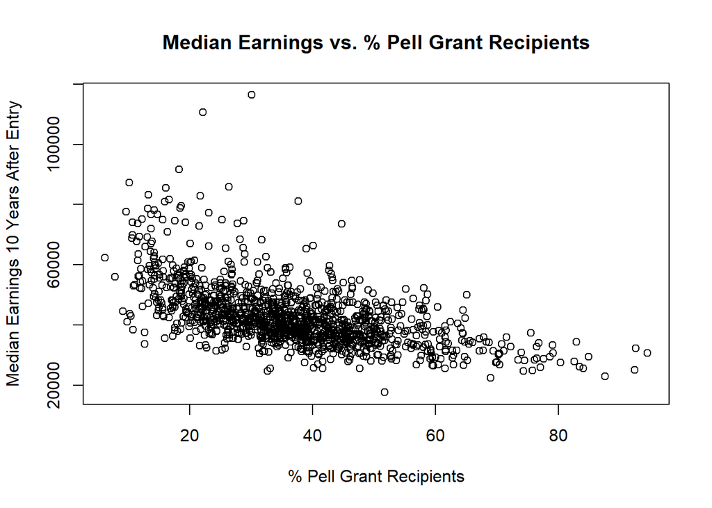

```r
plot(college_data$pctpell, college_data$earn10yr,
main="Median Earnings vs. % Pell Grant Recipients",
xlab="% Pell Grant Recipients",
ylab="Median Earnings 10 Years After Entry")
```

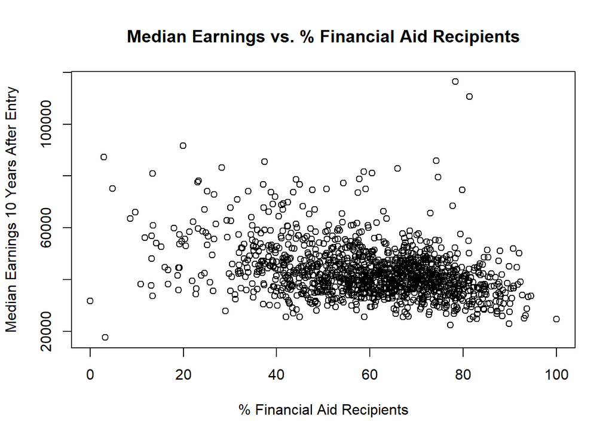

```r
plot(college_data$pctfloan, college_data$earn10yr,
main="Median Earnings vs. % Financial Aid Recipients",
xlab="% Financial Aid Recipients",
ylab="Median Earnings 10 Years After Entry")
```

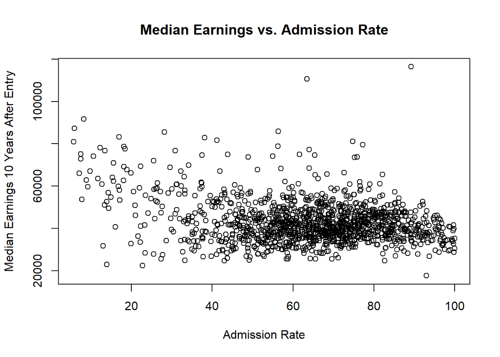

```r
plot(college_data$adm_rate, college_data$earn10yr,
main="Median Earnings vs. Admission Rate",
xlab="Admission Rate",
ylab="Median Earnings 10 Years After Entry")
```

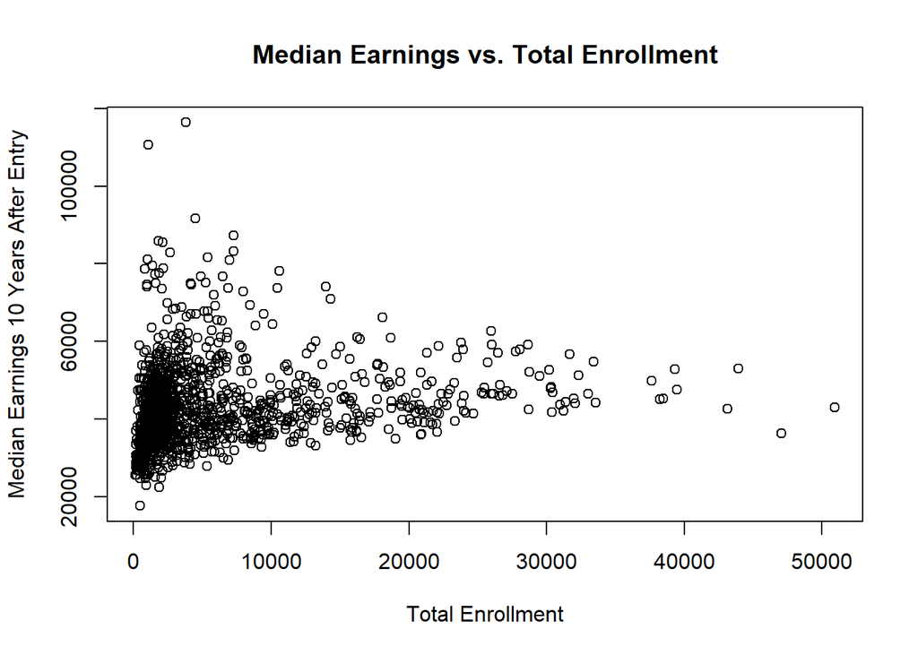

```r
plot(college_data$enrollment, college_data$earn10yr,
main="Median Earnings vs. Total Enrollment",
xlab="Total Enrollment",
ylab="Median Earnings 10 Years After Entry")
```

It appears that there is a negative relationship between median earnings and the percentage of students receiving Pell grants, financial aid, and possibly admission rate. The relationship between median earnings and total enrollment is not as clear.

## 3.7 Initial Categorical Boxplots

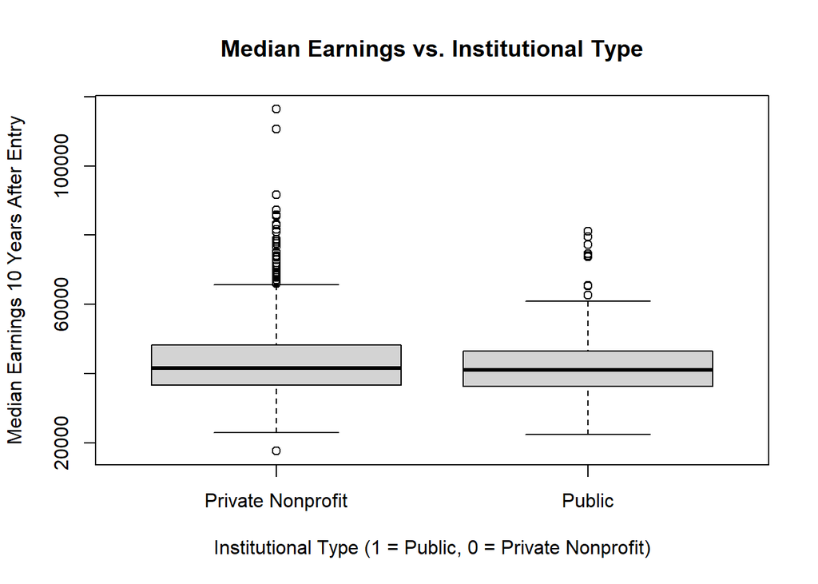

```r
boxplot(earn10yr ~ is_public, data = college_data,
        main = "Median Earnings vs. Institutional Type",
        xlab = "Institutional Type (1 = Public, 0 = Private Nonprofit)",
        ylab = "Median Earnings 10 Years After Entry",
        names = c("Private Nonprofit", "Public"))
```

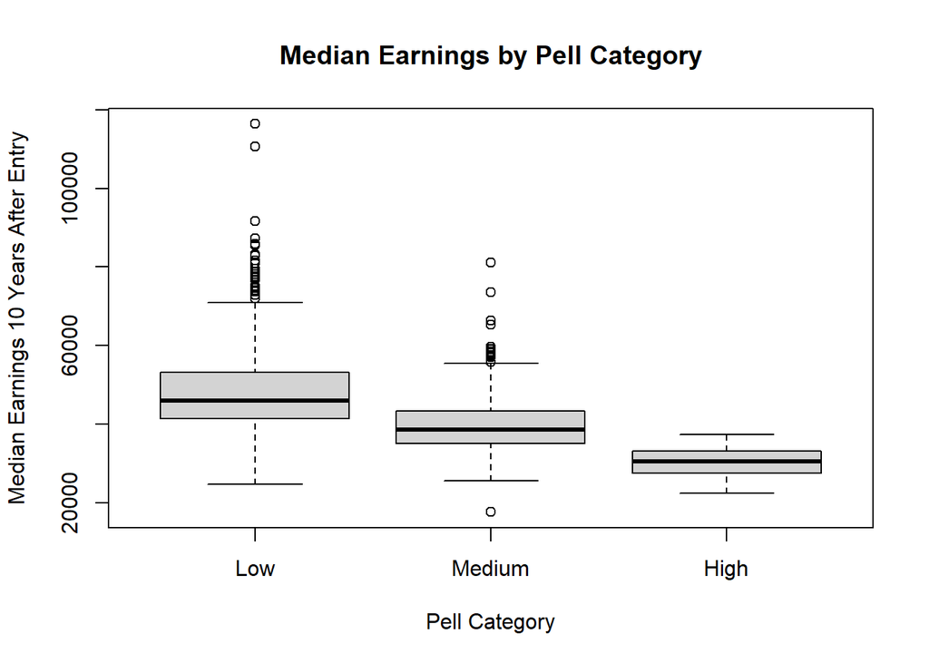

```r
college_data$pell_group <- with(college_data,
  ifelse(pell_cat_low == 1, "Low",
  ifelse(pell_cat_medium == 1, "Medium",
  ifelse(pell_cat_high == 1, "High", NA))))
college_data$pell_group <- factor(college_data$pell_group, levels = c("Low", "Medium", "High"))

boxplot(earn10yr ~ pell_group, data = college_data,
        main = "Median Earnings by Pell Category",
        xlab = "Pell Category", ylab = "Median Earnings 10 Years After Entry")
```

The change in median earnings across the three Pell grant categories is evident. —

# Section 4: Exploratory Data Analysis

## 4.1 Correlation Analysis

```r
# Select only numeric columns for correlation
numeric_cols <- college_data[, sapply(college_data, is.numeric)]
corr_results <- rcorr(as.matrix(numeric_cols))
# View correlation coefficients (rounded to 3 decimal places)
round(corr_results$r, 3)
```

```
##                 unitid control adm_rate sat_avg enrollment pctpell pctfloan
## unitid           1.000  -0.042    0.070  -0.048     -0.075  -0.052    0.035
## control         -0.042   1.000   -0.152   0.140     -0.553  -0.087    0.272
## adm_rate         0.070  -0.152    1.000  -0.362     -0.032   0.079    0.269
## sat_avg         -0.048   0.140   -0.362   1.000      0.224  -0.742   -0.526
## enrollment      -0.075  -0.553   -0.032   0.224      1.000  -0.137   -0.376
## pctpell         -0.052  -0.087    0.079  -0.742     -0.137   1.000    0.504
## pctfloan         0.035   0.272    0.269  -0.526     -0.376   0.504    1.000
## avg_net_price   -0.042   0.614   -0.088   0.392     -0.231  -0.457    0.122
## grad_rate        0.014   0.229   -0.295   0.832      0.173  -0.719   -0.339
## retention_rate  -0.078   0.012   -0.258   0.766      0.302  -0.628   -0.420
## earn10yr         0.002   0.081   -0.269   0.638      0.178  -0.569   -0.343
## pct_edu_program -0.013   0.004    0.165  -0.266     -0.133   0.171    0.207
## avg_facsalary   -0.025  -0.152   -0.326   0.662      0.412  -0.515   -0.501
## ft_faculty       0.028  -0.075   -0.039   0.136      0.053  -0.082   -0.063
## instr_expend    -0.050   0.122   -0.452   0.648      0.094  -0.410   -0.425
## pell_cat        -0.019  -0.088    0.053  -0.636     -0.112   0.851    0.428
## is_public        0.042  -1.000    0.152  -0.140      0.553   0.087   -0.272
## pell_cat_low     0.015   0.104   -0.097   0.601      0.093  -0.765   -0.385
## pell_cat_medium -0.009  -0.108    0.134  -0.488     -0.060   0.574    0.290
## pell_cat_high   -0.017   0.014   -0.105  -0.299     -0.087   0.509    0.256
##                 avg_net_price grad_rate retention_rate earn10yr pct_edu_program
## unitid                 -0.042     0.014         -0.078    0.002          -0.013
## control                 0.614     0.229          0.012    0.081           0.004
## adm_rate               -0.088    -0.295         -0.258   -0.269           0.165
## sat_avg                 0.392     0.832          0.766    0.638          -0.266
## enrollment             -0.231     0.173          0.302    0.178          -0.133
## pctpell                -0.457    -0.719         -0.628   -0.569           0.171
## pctfloan                0.122    -0.339         -0.420   -0.343           0.207
## avg_net_price           1.000     0.496          0.323    0.382          -0.220
## grad_rate               0.496     1.000          0.797    0.633          -0.216
## retention_rate          0.323     0.797          1.000    0.615          -0.289
## earn10yr                0.382     0.633          0.615    1.000          -0.368
## pct_edu_program        -0.220    -0.216         -0.289   -0.368           1.000
## avg_facsalary           0.242     0.617          0.652    0.690          -0.383
## ft_faculty             -0.076     0.103          0.064   -0.003           0.041
## instr_expend            0.246     0.549          0.488    0.513          -0.264
## pell_cat               -0.436    -0.631         -0.565   -0.499           0.187
## is_public              -0.614    -0.229         -0.012   -0.081          -0.004
## pell_cat_low            0.448     0.619          0.543    0.472          -0.191
```

[output cut: 29 more lines]

```
## pctpell               -0.765           0.574         0.509
## pctfloan              -0.385           0.290         0.256
## avg_net_price          0.448          -0.405        -0.108
## grad_rate              0.619          -0.528        -0.235
## retention_rate         0.543          -0.450        -0.242
## earn10yr               0.472          -0.383        -0.235
## pct_edu_program       -0.191           0.172         0.048
## avg_facsalary          0.448          -0.390        -0.149
## ft_faculty             0.095          -0.101         0.020
## instr_expend           0.351          -0.320        -0.077
## pell_cat              -0.947           0.770         0.465
## is_public             -0.104           0.108        -0.014
## pell_cat_low           1.000          -0.935        -0.156
## pell_cat_medium       -0.935           1.000        -0.206
## pell_cat_high         -0.156          -0.206         1.000
```

```r
# View p-values (rounded to 4 decimal places)
round(corr_results$P, 4)
```

```
##                 unitid control adm_rate sat_avg enrollment pctpell pctfloan
## unitid              NA  0.1222   0.0112  0.0796     0.0065  0.0592   0.2062
## control         0.1222      NA   0.0000  0.0000     0.0000  0.0015   0.0000
## adm_rate        0.0112  0.0000       NA  0.0000     0.2483  0.0039   0.0000
## sat_avg         0.0796  0.0000   0.0000      NA     0.0000  0.0000   0.0000
## enrollment      0.0065  0.0000   0.2483  0.0000         NA  0.0000   0.0000
## pctpell         0.0592  0.0015   0.0039  0.0000     0.0000      NA   0.0000
## pctfloan        0.2062  0.0000   0.0000  0.0000     0.0000  0.0000       NA
## avg_net_price   0.1219  0.0000   0.0014  0.0000     0.0000  0.0000   0.0000
## grad_rate       0.6055  0.0000   0.0000  0.0000     0.0000  0.0000   0.0000
## retention_rate  0.0045  0.6634   0.0000  0.0000     0.0000  0.0000   0.0000
## earn10yr        0.9423  0.0033   0.0000  0.0000     0.0000  0.0000   0.0000
## pct_edu_program 0.6475  0.8976   0.0000  0.0000     0.0000  0.0000   0.0000
## avg_facsalary   0.3717  0.0000   0.0000  0.0000     0.0000  0.0000   0.0000
## ft_faculty      0.3110  0.0060   0.1567  0.0000     0.0536  0.0029   0.0228
## instr_expend    0.0708  0.0000   0.0000  0.0000     0.0006  0.0000   0.0000
## pell_cat        0.4915  0.0013   0.0547  0.0000     0.0000  0.0000   0.0000
## is_public       0.1222  0.0000   0.0000  0.0000     0.0000  0.0015   0.0000
## pell_cat_low    0.5879  0.0002   0.0004  0.0000     0.0007  0.0000   0.0000
## pell_cat_medium 0.7542  0.0001   0.0000  0.0000     0.0276  0.0000   0.0000
## pell_cat_high   0.5347  0.6006   0.0001  0.0000     0.0014  0.0000   0.0000
##                 avg_net_price grad_rate retention_rate earn10yr pct_edu_program
## unitid                 0.1219    0.6055         0.0045   0.9423          0.6475
## control                0.0000    0.0000         0.6634   0.0033          0.8976
## adm_rate               0.0014    0.0000         0.0000   0.0000          0.0000
## sat_avg                0.0000    0.0000         0.0000   0.0000          0.0000
## enrollment             0.0000    0.0000         0.0000   0.0000          0.0000
## pctpell                0.0000    0.0000         0.0000   0.0000          0.0000
## pctfloan               0.0000    0.0000         0.0000   0.0000          0.0000
## avg_net_price              NA    0.0000         0.0000   0.0000          0.0000
## grad_rate              0.0000        NA         0.0000   0.0000          0.0000
## retention_rate         0.0000    0.0000             NA   0.0000          0.0000
## earn10yr               0.0000    0.0000         0.0000       NA          0.0000
## pct_edu_program        0.0000    0.0000         0.0000   0.0000              NA
## avg_facsalary          0.0000    0.0000         0.0000   0.0000          0.0000
## ft_faculty             0.0054    0.0002         0.0195   0.8997          0.1316
## instr_expend           0.0000    0.0000         0.0000   0.0000          0.0000
## pell_cat               0.0000    0.0000         0.0000   0.0000          0.0000
## is_public              0.0000    0.0000         0.6634   0.0033          0.8976
## pell_cat_low           0.0000    0.0000         0.0000   0.0000          0.0000
```

[output cut: 29 more lines]

```
## pctpell               0.0000          0.0000        0.0000
## pctfloan              0.0000          0.0000        0.0000
## avg_net_price         0.0000          0.0000        0.0001
## grad_rate             0.0000          0.0000        0.0000
## retention_rate        0.0000          0.0000        0.0000
## earn10yr              0.0000          0.0000        0.0000
## pct_edu_program       0.0000          0.0000        0.0808
## avg_facsalary         0.0000          0.0000        0.0000
## ft_faculty            0.0006          0.0002        0.4756
## instr_expend          0.0000          0.0000        0.0048
## pell_cat              0.0000          0.0000        0.0000
## is_public             0.0002          0.0001        0.6006
## pell_cat_low              NA          0.0000        0.0000
## pell_cat_medium       0.0000              NA        0.0000
## pell_cat_high         0.0000          0.0000            NA
```

```r
write.csv(round(corr_results$r, 3), file = "Correlation Matrix College Scorecard.csv")
```

## 4.2 Visualization: Correlation Matrix

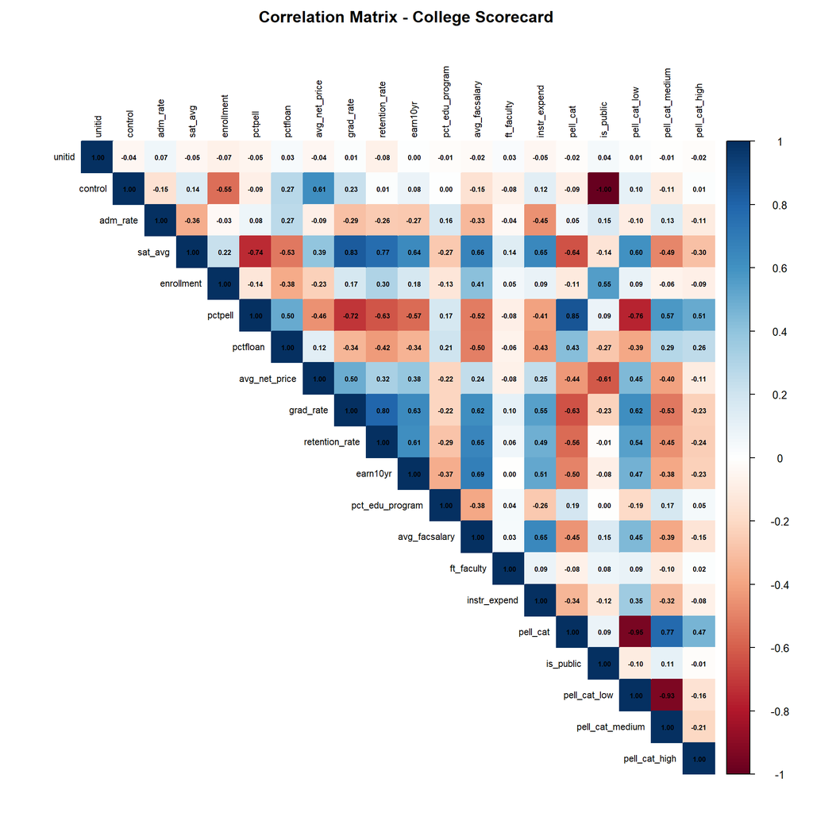

```r
corrplot(corr_results$r, method = "color", type = "upper",
         tl.cex = 0.7, tl.col = "black",
         addCoef.col = "black", number.cex = 0.5,
         title = "Correlation Matrix - College Scorecard",
         mar = c(0, 0, 2, 0))
```

## 4.3 Density Plot: Median Earnings by Pell Grant Category

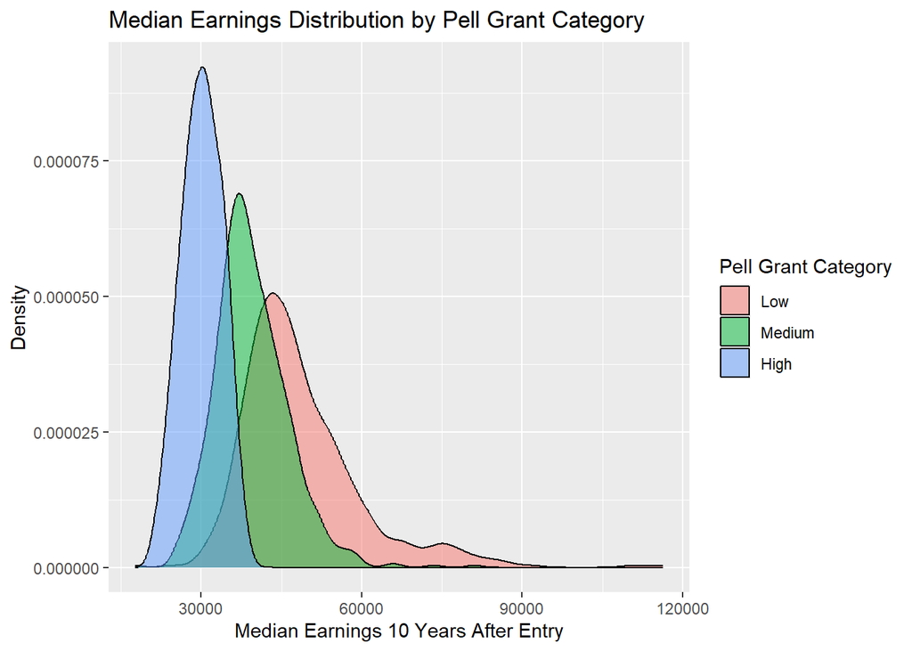

```r
college_data$pell_cat_label <- factor(college_data$pell_cat,
labels = c("Low", "Medium", "High"))

ggplot(college_data, aes(x = earn10yr, fill = as.factor(pell_cat_label))) +
  geom_density(alpha = 0.5) +
  labs(title = "Median Earnings Distribution by Pell Grant Category",
       x = "Median Earnings 10 Years After Entry",
       y = "Density",
       fill = "Pell Grant Category")
```

Average SAT score (0.638), First-year retention rate (0.615), Six-year graduation rate (0.633), First-year retention rate (0.615), Average faculty monthly salary (0.690), Percent receiving Pell grants (-0.569), Instructional expenditure per FTE student (0.513), and Pell grant category (-0.499) have the strongest correlations with median earnings.

# Section 5: Bivariate Regression Analysis

## 5.1 Regression Analysis: Median Earnings vs. Percentage of Students Receiving Pell Grants

```r
model_pell <- lm(earn10yr ~ pctpell, data = college_data)
summary(model_pell)
```

```
##
## Call:
## lm(formula = earn10yr ~ pctpell, data = college_data)
##
## Residuals:
##    Min     1Q Median     3Q    Max
## -19880  -5118  -1274   3891  70878
##
## Coefficients:
##             Estimate Std. Error t value            Pr(>|t|)
## (Intercept) 57669.97     629.02   91.68 <0.0000000000000002 ***
## pctpell      -403.73      16.06  -25.14 <0.0000000000000002 ***
## ---
## Signif. codes:  0 '***' 0.001 '**' 0.01 '*' 0.05 '.' 0.1 ' ' 1
##
## Residual standard error: 8339 on 1324 degrees of freedom
## Multiple R-squared:  0.3232, Adjusted R-squared:  0.3227
## F-statistic: 632.3 on 1 and 1324 DF,  p-value: < 0.00000000000000022
```

The slope coefficient is -403.73, which is statistically significant at the 0.001 level, and with an R-squared of 0.3232. This means that for every 1% increase in the percentage of students receiving Pell grants, the median earnings 10 years after entry is expected to decrease by $403.73.

# Section 6: Regression Diagnostics – Bivariate Regression

## 6.1 Histogram of Standardized Residuals

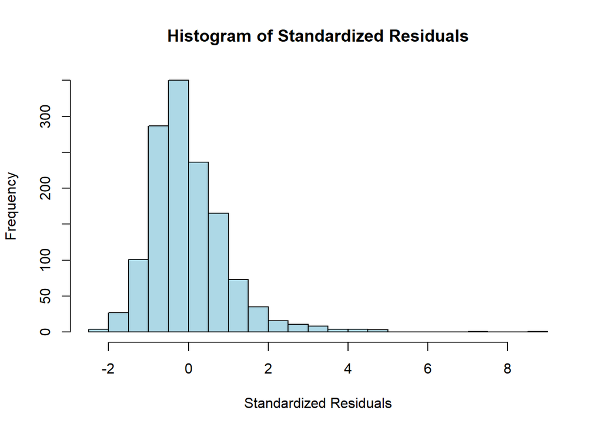

```r
hist(scale(model_pell$residuals),
     main = "Histogram of Standardized Residuals",
     xlab = "Standardized Residuals",
     col = "lightblue",
     breaks = 20)
```

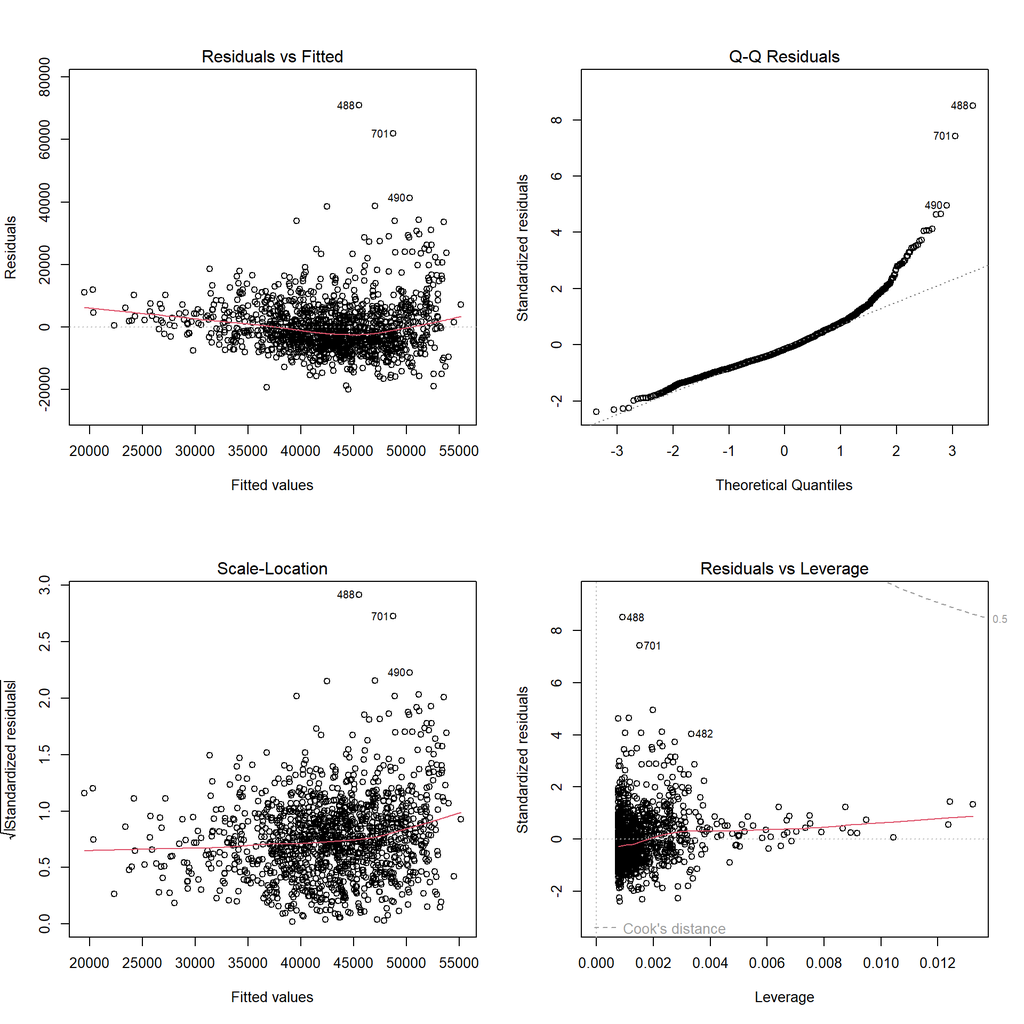

```r
par(mfrow = c(2, 2))
plot(model_pell)
```

```r
par(mfrow = c(1, 1))
```

## 6.3 Standardized Coefficients

```r
lm(scale(earn10yr) ~ scale(pctpell), data = college_data)
```

```
##
## Call:
## lm(formula = scale(earn10yr) ~ scale(pctpell), data = college_data)
##
## Coefficients:
##            (Intercept)          scale(pctpell)
## -0.0000000000000001943  -0.5685046662959296615
```

```r
lm(scale(earn10yr) ~ scale(pell_cat), data = college_data)
```

```
##
## Call:
## lm(formula = scale(earn10yr) ~ scale(pell_cat), data = college_data)
##
## Coefficients:
##           (Intercept)        scale(pell_cat)
## -0.000000000000002088  -0.498976227193217325
```

```r
lm(scale(earn10yr) ~ scale(pctfloan), data = college_data)
```

```
##
## Call:
## lm(formula = scale(earn10yr) ~ scale(pctfloan), data = college_data)
##
## Coefficients:
##            (Intercept)         scale(pctfloan)
## -0.0000000000000002368  -0.3429332815211152408
```

```r
lm(scale(earn10yr) ~ scale(adm_rate), data = college_data)
```

```
##
## Call:
## lm(formula = scale(earn10yr) ~ scale(adm_rate), data = college_data)
##
## Coefficients:
##            (Intercept)         scale(adm_rate)
## -0.0000000000000003061  -0.2687809287199865449
```

```r
lm(scale(earn10yr) ~ scale(enrollment), data = college_data)
```

```
##
## Call:
## lm(formula = scale(earn10yr) ~ scale(enrollment), data = college_data)
##
## Coefficients:
##            (Intercept)       scale(enrollment)
## -0.0000000000000002095   0.1782549759981875148
```

```r
lm(scale(earn10yr) ~ scale(control), data = college_data)
```

```
##
## Call:
## lm(formula = scale(earn10yr) ~ scale(control), data = college_data)
##
## Coefficients:
##            (Intercept)          scale(control)
## -0.0000000000000001407   0.0806537491864878359
```

## 6.4 Standardized Residuals – Identifying Outliers

```r
model_pell$standardized.residuals <- rstandard(model_pell)
model_pell$large_residual <- abs(model_pell$standardized.residuals) > 2

# How many potential outliers?
sum(model_pell$large_residual)
```

```
## [1] 52
```

There are 52 potential outliers in the (model_pell) regression with a standardized residual greater than 2.

## 6.5 Durbin-Watson Test

We are doing a Durbin-Watson test to check for autocorrelation in the residuals to see if errors are independent of each other.

```r
dwt(model_pell)
```

```
##  lag Autocorrelation D-W Statistic p-value
##    1       0.1877696      1.624395       0
##  Alternative hypothesis: rho != 0
```

# Section 7: Sequential Model Building

## 7.2 Regression Analysis: Median Earnings vs. Pell Grant Category

```r
model_pell_cat <- lm(earn10yr ~ pell_cat_low + pell_cat_medium + pell_cat_high, data = college_data)
summary(model_pell_cat)
```

```
##
## Call:
## lm(formula = earn10yr ~ pell_cat_low + pell_cat_medium + pell_cat_high,
##     data = college_data)
##
## Residuals:
##    Min     1Q Median     3Q    Max
## -24021  -5453  -1321   4085  67779
##
## Coefficients: (1 not defined because of singularities)
##                 Estimate Std. Error t value             Pr(>|t|)
## (Intercept)        30114       1325  22.731 < 0.0000000000000002 ***
## pell_cat_low       18507       1377  13.442 < 0.0000000000000002 ***
## pell_cat_medium     9339       1364   6.847      0.0000000000115 ***
## pell_cat_high         NA         NA      NA                   NA
## ---
## Signif. codes:  0 '***' 0.001 '**' 0.01 '*' 0.05 '.' 0.1 ' ' 1
##
## Residual standard error: 8787 on 1323 degrees of freedom
## Multiple R-squared:  0.249,  Adjusted R-squared:  0.2478
## F-statistic: 219.3 on 2 and 1323 DF,  p-value: < 0.00000000000000022
```

As the baseline, the intercept for pell_cat_high is 30114, which is statistically significant at the 0.001 level, and with an R-squared of 0.249. This means for a student that falls in the highest Pell grant category (>66%) the median earnings 10 years after entry is expected to be $30,114.

The coefficient for pell_cat_medium is 9339, which is statistically significant at the 0.001 level, and with an R-squared of 0.249. This means for a student that falls in the middle Pell grant category (33-66%), the median earnings 10 years after entry is expected to be $9,339 higher than the estimate for the highest Pell Grant category, resulting in a total estimate of $39,453.

The coefficient for pell_cat_low is 18507, which is statistically significant at the 0.001 level, and with an R-squared of 0.249. This means for a student that falls in the lowest Pell grant category (0-33%), the median earnings 10 years after entry is expected to be $18,507 higher than the estimate for the highest Pell Grant category, resulting in a total estimate of $48,621.

## 7.3 Regression Analysis: Median Earnings vs. Percentage of Students Receiving Financial Aid

```r
model_financial_aid <- lm(earn10yr ~ pctfloan, data = college_data)
summary(model_financial_aid)
```

```
##
## Call:
## lm(formula = earn10yr ~ pctfloan, data = college_data)
##
## Residuals:
##    Min     1Q Median     3Q    Max
## -37373  -5983  -1015   4376  77278
##
## Coefficients:
##             Estimate Std. Error t value            Pr(>|t|)
## (Intercept)  55657.3      992.5   56.08 <0.0000000000000002 ***
## pctfloan      -211.2       15.9  -13.28 <0.0000000000000002 ***
## ---
## Signif. codes:  0 '***' 0.001 '**' 0.01 '*' 0.05 '.' 0.1 ' ' 1
##
## Residual standard error: 9522 on 1324 degrees of freedom
## Multiple R-squared:  0.1176, Adjusted R-squared:  0.1169
## F-statistic: 176.5 on 1 and 1324 DF,  p-value: < 0.00000000000000022
```

The slope coefficient is -211.2, which is statistically significant at the 0.001 level, and with an R-squared of 0.1176. This means that for every 1% increase in the percentage of students receiving financial aid, the median earnings 10 years after entry is expected to decrease by $211.2.

## 7.4 Regression Analysis: Median Earnings vs. Admission Rate

```r
model_adm_rate <- lm(earn10yr ~ adm_rate, data = college_data)
summary(model_adm_rate)
```

```
##
## Call:
## lm(formula = earn10yr ~ adm_rate, data = college_data)
##
## Residuals:
##    Min     1Q Median     3Q    Max
## -27398  -5727   -970   5178  77121
##
## Coefficients:
##             Estimate Std. Error t value            Pr(>|t|)
## (Intercept)  52324.5      962.5   54.37 <0.0000000000000002 ***
## adm_rate      -146.2       14.4  -10.15 <0.0000000000000002 ***
## ---
## Signif. codes:  0 '***' 0.001 '**' 0.01 '*' 0.05 '.' 0.1 ' ' 1
##
## Residual standard error: 9763 on 1324 degrees of freedom
## Multiple R-squared:  0.07224,    Adjusted R-squared:  0.07154
## F-statistic: 103.1 on 1 and 1324 DF,  p-value: < 0.00000000000000022
```

The slope coefficient is -146.2, which is statistically significant at the 0.001 level, and with an R-squared of 0.0722. This means that for every 1% increase in admission rate, the median earnings 10 years after entry is expected to decrease by $146.2.

## 7.5 Regression Analysis: Median Earnings vs. Total Enrollment

```r
model_enrollment <- lm(earn10yr ~ enrollment, data = college_data)
summary(model_enrollment)
```

```
##
## Call:
## lm(formula = earn10yr ~ enrollment, data = college_data)
##
## Residuals:
##    Min     1Q Median     3Q    Max
## -24050  -6344  -1856   4159  73907
##
## Coefficients:
##                Estimate  Std. Error t value             Pr(>|t|)
## (Intercept) 41535.13853   346.94185 119.718 < 0.0000000000000002 ***
## enrollment      0.25161     0.03817   6.592      0.0000000000626 ***
## ---
## Signif. codes:  0 '***' 0.001 '**' 0.01 '*' 0.05 '.' 0.1 ' ' 1
##
## Residual standard error: 9974 on 1324 degrees of freedom
## Multiple R-squared:  0.03177,    Adjusted R-squared:  0.03104
## F-statistic: 43.45 on 1 and 1324 DF,  p-value: 0.00000000006263
```

The slope coefficient is 0.2516, which is statistically significant at the 0.001 level, and with an R-squared of 0.03177. This means that for each additional enrollment in total enrollment, the median earnings 10 years after entry is expected to increase by $0.2516.

## 7.6 Regression Analysis: Median Earnings vs. Institutional Type

```r
model_control <- lm(earn10yr ~ is_public, data = college_data)
summary(model_control)
```

```
##
## Call:
## lm(formula = earn10yr ~ is_public, data = college_data)
##
## Residuals:
##    Min     1Q Median     3Q    Max
## -25976  -6455  -1584   4608  72824
##
## Coefficients:
##             Estimate Std. Error t value             Pr(>|t|)
## (Intercept)    43577        352 123.810 < 0.0000000000000002 ***
## is_public      -1684        572  -2.944              0.00329 **
## ---
## Signif. codes:  0 '***' 0.001 '**' 0.01 '*' 0.05 '.' 0.1 ' ' 1
##
## Residual standard error: 10100 on 1324 degrees of freedom
## Multiple R-squared:  0.006505,   Adjusted R-squared:  0.005755
## F-statistic: 8.669 on 1 and 1324 DF,  p-value: 0.003293
```

## 7.7 Final Model

```r
model_final <- lm(earn10yr ~ pctpell + pell_cat_high + pell_cat_medium + pctfloan + adm_rate + enrollment + is_public, data = college_data)
summary(model_final)
```

```
##
## Call:
## lm(formula = earn10yr ~ pctpell + pell_cat_high + pell_cat_medium +
##     pctfloan + adm_rate + enrollment + is_public, data = college_data)
##
## Residuals:
##    Min     1Q Median     3Q    Max
## -18248  -4788  -1063   3381  72946
##
## Coefficients:
##                    Estimate  Std. Error t value             Pr(>|t|)
## (Intercept)     62551.20365  1203.98865  51.953 < 0.0000000000000002 ***
## pctpell          -349.41734    31.72666 -11.013 < 0.0000000000000002 ***
## pell_cat_high    -685.55815  2017.68555  -0.340              0.73408
## pell_cat_medium -1270.57353   757.78268  -1.677              0.09384 .
## pctfloan           11.21493    17.83952   0.629              0.52968
## adm_rate         -114.97508    12.86613  -8.936 < 0.0000000000000002 ***
## enrollment          0.20901     0.03823   5.467         0.0000000547 ***
## is_public       -1584.43997   584.98811  -2.708              0.00685 **
## ---
## Signif. codes:  0 '***' 0.001 '**' 0.01 '*' 0.05 '.' 0.1 ' ' 1
##
## Residual standard error: 7938 on 1318 degrees of freedom
## Multiple R-squared:  0.3895, Adjusted R-squared:  0.3863
## F-statistic: 120.1 on 7 and 1318 DF,  p-value: < 0.00000000000000022
```

# Section 8: Final Model Diagnostics

## 8.1 Histogram of Standardized Residuals

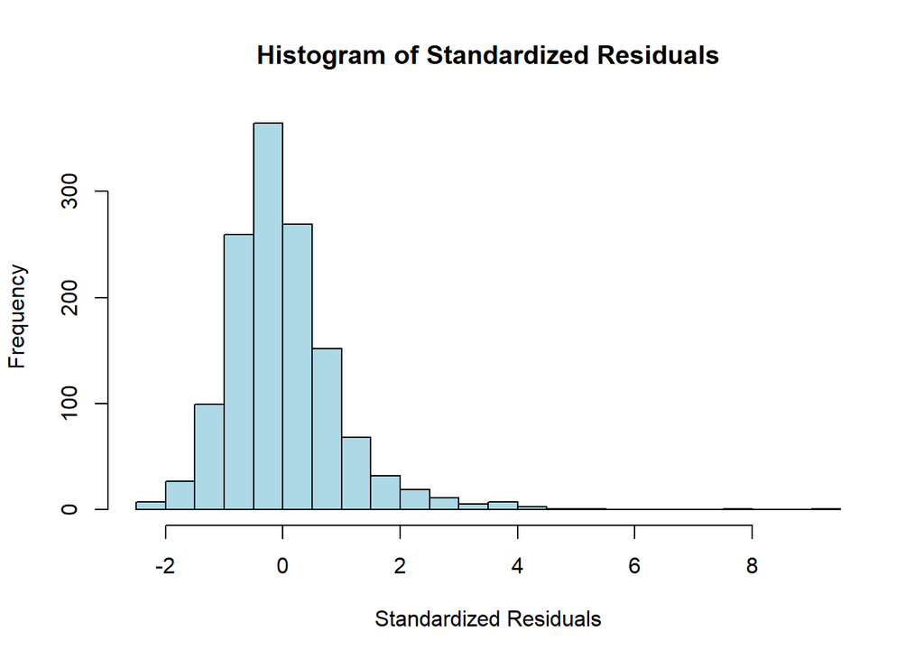

```r
hist(scale(model_final$residuals),
     main = "Histogram of Standardized Residuals",
     xlab = "Standardized Residuals",
     col = "lightblue",
     breaks = 20)
```

## 8.2 Diagnostic Plots

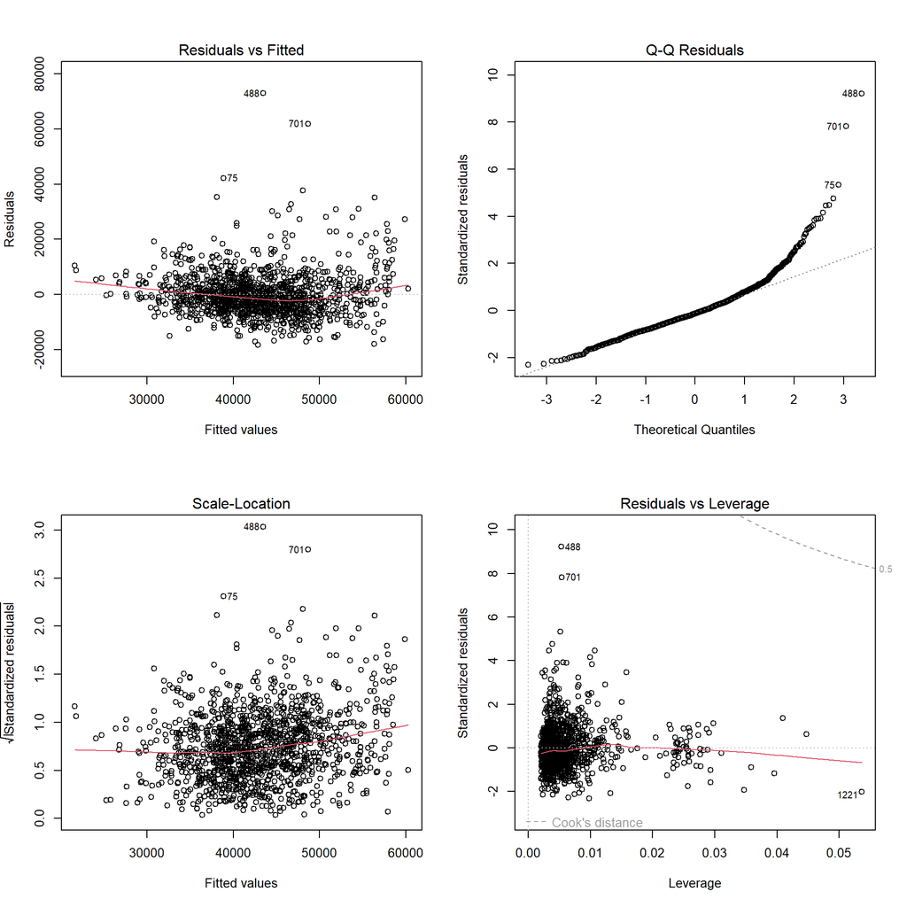

```r
par(mfrow = c(2, 2))
plot(model_final)
```

```r
par(mfrow = c(1, 1))
```

## 8.3 Standardized Residuals

```r
model_final$standardized.residuals <- rstandard(model_final)
model_final$large_residual <- abs(model_final$standardized.residuals) > 2

# How many potential outliers in the final model?
sum(model_final$large_residual)
```

```
## [1] 57
```

## 8.4 Standardized Coefficients

```r
lm(scale(earn10yr) ~ scale(pctpell) + scale(pell_cat) + scale(pctfloan) + scale(adm_rate) + scale(enrollment) + scale(control), data = college_data)
```

```
##
## Call:
## lm(formula = scale(earn10yr) ~ scale(pctpell) + scale(pell_cat) +
##     scale(pctfloan) + scale(adm_rate) + scale(enrollment) + scale(control),
##     data = college_data)
##
## Coefficients:
##            (Intercept)          scale(pctpell)         scale(pell_cat)
## -0.0000000000000004739  -0.4784615100763488504  -0.0653164360650257264
##        scale(pctfloan)         scale(adm_rate)       scale(enrollment)
##  0.0193096520575357644  -0.2161784133614776393   0.1483285421921900493
##         scale(control)
##  0.0769570056291549870
```

Percentage of students receiving Pell grants (pctpell), admission rate (adm_rate), and total enrollment (enrollment) have the largest effects here.

## 8.5 Variance Inflation Factor (VIF)

```r
vif(model_final)
```

```
##         pctpell   pell_cat_high pell_cat_medium        pctfloan        adm_rate
##        4.308811        2.748487        2.987405        1.811859        1.207389
##      enrollment       is_public
##        1.583720        1.694225
```

The VIFs are all below 5, which indicates no multicollinearity in the model.

## 8.6 Durbin-Watson Test

```r
dwt(model_final)
```

```
##  lag Autocorrelation D-W Statistic p-value
##    1       0.1533699      1.693007       0
##  Alternative hypothesis: rho != 0
```

# Section 9: Summary and Interpretation

## 9.1 Summary

The final regression model is statistically significant (p < 0.001) with about 39% (Adjusted R-squared = 0.386) of the variation in earnings after 10 years of graduation accounted for by the predictions of the model. Several variables significantly predict earnings:

1. **Percent of students receiving Pell Grants** (pctpell) is a strong negative predictor (β = −349.4, p < .001). Colleges with higher proportions of Pell recipients tend to have lower average post-graduation earnings.
2. **Admission rate** (adm_rate) is also negatively associated with earnings (β = −114.98, p < .001), suggesting that more selective institutions (lower admission rates) are associated with higher graduate earnings.
3. **Enrollment size** (enrollment) shows a small but significant positive effect (β = 0.209, p < .001), meaning larger institutions tend to have slightly higher average earnings outcomes.
4. **Institution type** (is_public) shows a noticeable difference, with public institutions showing significantly lower predicted earnings compared with private institutions (β = −1584.44, p = .0069).

## 9.3 Limitations

Although this regression analysis offers valuable findings, it is important to recognize several key limitations:

1. **Correlation Does Not Imply Causation:** Because the analysis relies on observational rather than experimental data, any associations identified cannot be taken as evidence of causality. The relationships observed between institutional characteristics and graduate earnings may be influenced by underlying factors not included in the model.
2. **Potential for Omitted Variables:** There may be important factors affecting post-graduation earnings—such as academic rigor, local job markets, or student demographics—that were not measured or included. Excluding these variables could bias the estimated effects of the predictors used.
3. **Limits to Generalizability:** The model is built on a specific dataset covering certain colleges and a particular cohort (10-year earnings). As such, its findings may not extend to all higher education contexts, different cohorts, or international settings.
4. **Multicollinearity and Specification:** Even though VIFs suggest multicollinearity is not severe, some predictors may still be correlated, complicating interpretation of individual effects.
5. **Outliers and Model Robustness:** While outliers were identified based on standardized residuals, they were not specifically adjusted for or examined further, which could impact the reliability of the results.

Altogether, these limitations mean the results should be interpreted with care. Further research with more comprehensive data, carefully selected variables, and alternative modeling approaches is needed to more fully understand the factors influencing graduate earnings.